# Notebook

**Research Question:** "Cost is the constraint. Can a *cheap* open-source model do the value-confirmation that Opus does — reliably enough, and safely enough — to keep Opus out of the hot path?"

*Grades cheap OSS judges against the Opus re-score on the same 4,237 field-values, with reliability, a false-confirm safety metric, cheap-consensus, and a $0 deterministic baseline.*

## The problem — verifying coded values at corpus scale

**Where this sits.** Judgement ⑪ (*variable coding*) is the second step of the extraction track: given a fixed schema of ~37 patient covariates — age, conditions, medications, dosage, functional status, symptom trajectory, and so on — it reads each Reddit post and fills in the values. **These covariates are exactly what the planned clustering study will cluster patients on.** If their values are wrong or inconsistent, the clusters measure noise rather than patients, so the correctness of ⑪ is load-bearing for the whole project.

**How we got here.** ⑪ first looked alarming: coded values agreed with the Opus reference only ~28% of the time by Jaccard set-overlap. The sibling notebook (`j11_value_rejudge`) re-scored the same codings with an Opus *semantic* judge and showed most of that was a **measurement artifact** — `"2"` vs `"at least 2"` scores 0 by set-overlap but means the same thing (~82% of values are semantically right). But it left a real **~18% genuine-error tail**, concentrated in the interpretive free-text fields. Either way, the fix requires *verifying* values — canonicalising the artifacts, catching the real errors — not blindly trusting the raw extraction.

**The cost problem this notebook is about.** The plan's architecture is **produce-then-verify**: a cheap model extracts, and a strong model checks its work. Production is eventually **Opus on the whole corpus** — but Opus as the verifier costs ~$5 / 1M input tokens, and at corpus scale (hundreds of thousands of posts × 37 fields) you cannot run it on every value. Hence the question: **can a *cheap* open-source model do the value-confirmation instead**, keeping expensive Opus for only the hard residual?

**What "confirm" means here, concretely.** For each coded field-value the judge makes one narrow, checkable call — *is this value semantically equivalent to the reference?* — used as a **triage gate**: *confirm* → skip it, *flag* → escalate to a frontier panel. It is deliberately the *easy* confirm: the judge compares two short strings and never re-reads the post.

**Why it is not obviously a yes.** Verification is easier than generation, so a cheap judge *might* suffice — but four things can break it, and each is a section below: a cheap model may not reliably emit parseable output at all (**reliability**, §1); it may be a **yes-man** that confirms everything, real errors included (**safety**, §2); its agreement with Opus is *mimicry, not truth* — Opus is the reference here, not ground truth (§3, §7); and a free deterministic string-match may already do the easy job the LLM is being paid for (§5). This notebook is built to catch each of those, rather than report a single flattering "% agreement" number.

**How many values are off.** Across the **37-field schema** and **4,237** co-populated values, the Opus semantic judge ruled **62% equivalent**, **20% a correct-but-less-complete subset**, and **18% genuinely different** — a real coding error. So ~1 in 6 co-populated values is genuinely wrong, but the error is **not spread evenly**: **6 fields carry a genuine-error rate ≥ 25%** (`healthcare_system` 47%, `alternative_treatments` 34%, `functional_status_tier` 30%, `conditions` 30%, `social_impact` 30%, `symptom_trajectory` 29%), while **18 fields sit under 10%** (the numeric / identity / geo fields).

**By value type — the error climbs from numeric to open free-text**

| value type | # fields | genuine-error (wtd) | # wrong values |
| --- | --- | --- | --- |
| numeric | 7 | 11% | 62 |
| ontology | 11 | 17% | 337 |
| fixed enum | 10 | 19% | 176 |
| open text | 9 | 23% | 170 |

**By fix tier — most FIELDS are cleanable; most ERRORS are not**

| fix tier | # fields | genuine-error (wtd) | share of all errors |
| --- | --- | --- | --- |
| 1. deterministic post-collection | 21 | 8% | 21% |
| 2. tool + rule (ontology / designed enum) | 7 | 27% | 56% |
| 3. judge panel / field redesign | 9 | 23% | 23% |

**Which errors can be fixed after collection, and which can't.** The three tiers above map directly onto post-collection feasibility:

- **Tier 1 — deterministic post-collection (21 fields).** The correct value is recoverable from the extracted *string alone*: parse the number (`"at least 2"` → 2), look up the ontology (`"b12"` → RxNorm), or map to a fixed enum (`"alabama"` → AL). No LLM, no re-reading the post, fully re-runnable — and these already sit near zero error, so a normaliser just closes the residual. **Fully fixable after collection.**
- **Tier 2 — tool *and* rule (7 fields, the messy middle).** An ontology map fixes the surface-form half post-collection, but the rest is a **schema-boundary** decision no map can make (is PEM a *condition*? is famotidine an *alternative treatment*?) — a one-time written rule — and the three ordinal fields (`functional_status_tier`, `activity_level`, `symptom_trajectory`) are better constrained to a designed scale **at extraction** than mapped afterward. **Partly post-collection, partly not.**
- **Tier 3 — not fixable by cleanup (9 fields).** Here the disagreement is about *content*, not format, and Opus's own reference is just one debatable reading (on `healthcare_system`, a model saying "US" vs gold "Canada" can both be right when the post mentions both). No parser or ontology helps — you need a **judge panel** to decide whether it is a real error at all, or a **field redesign**. *(Three nominally-open fields — `family_history`, `hormonal_events`, `misdiagnosis` — score fine only because they are rare / small.)*

**The one-line version:** most of the *count* of fields is Tier 1 and cleanable after collection, but most of the *volume* of genuine errors lives in Tiers 2–3 — and the Tier-3 residual is exactly what the rest of this notebook asks whether a cheap model can help triage, instead of paying for Opus on every value.

```
Opus-ruled items: 4237 | cheap judges loaded: ['llama-4-scout', 'glm-4.7-flash', 'qwen3-30b']
```

*(loaded)*

**Abstract.** Grading cheap OSS judges against the Opus re-score on the same 4,237 ruled field-values. **Reliability splits them first:** llama-4-scout fails 6%, glm-4.7-flash fails 78%, qwen3-30b fails 21%. A model that can't emit parseable JSON is unusable before accuracy enters. **`glm-4.7-flash` (78%) is disqualified on reliability alone** — parse-failure well past the 25% usability line, before accuracy is even considered. **But reliability and safety trade off, and the reliable one loses on safety.** The most reliable judge `llama-4-scout` (6% fail) false-confirms **61%** — it waves through that share of the values Opus ruled *different*, no better than the $0 string-match baseline (61%). It is a **yes-man**: perfect formatting, no discrimination. The genuinely safer judge `qwen3-30b` false-confirms only 15% (κ=0.67) — but it is a *reasoning* model (21% fail, ~5× tokens, ~20s/call). **So no single cheap model is both reliable and safe.** What works is their **consensus**: where the reliable cheap judges (`llama-4-scout`, `qwen3-30b`) *both* say OK — **55%** of items — only **3%** are actually Opus-*different*. Two weak judges agreeing filters out the yes-man's errors. **Bottom line:** cheap confirmation works as a gate via **consensus** (or a slow reasoning judge), **not** via the cheap-and-reliable model alone — and this is the easy surface-form confirm, silent on the hard post-reading panel (Opus isn't ground truth here, and the judge never saw the post).

## 1. Reliability first — can it even answer?

Before accuracy: how often does each cheap judge emit a parseable verdict at all? Parse-failure is tracked as its own outcome (not silently coerced to 'different'), because a model that can't format is disqualified on reliability grounds — a separate axis from whether its judgments are right.

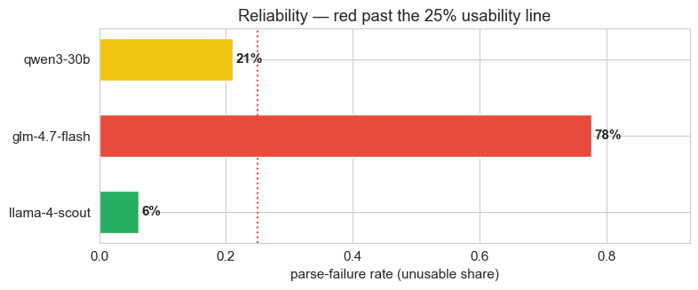

## 2. The safety metric — false-confirm, not raw agreement

For a triage gate the dangerous error is asymmetric: **waving through a value Opus ruled *different* (false-confirm) is a real error that leaks; flagging a good value (false-flag) is safe — it just costs a panel call.** Raw agreement hides this and is gamed by the 62%-equivalent majority (see the always-OK strawman). So we lead with false-confirm: `P(judge says OK | Opus said different)`.

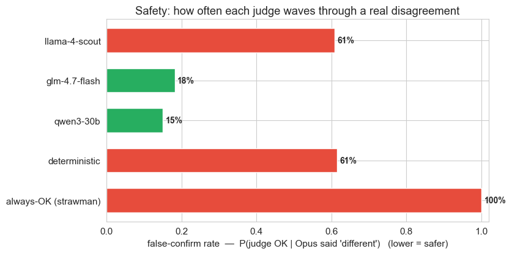

**What this shows:** the always-OK strawman leaks **100%** of real errors (and would score ~62% raw agreement — why raw agreement is worthless here). The best reliable cheap judge `qwen3-30b` leaks **15%**; the $0 deterministic rule leaks **61%**. Read that against the chart: the most *reliable* judge sits right at the deterministic line — reliable formatting, yes-man judging — so being reliable does not make a judge safe. A gate is only safe if this leak is low *or* caught downstream (see §4), paired with the escalate-on-doubt asymmetry, since a non-answer (parse fail) is a safe escalate, not a confirm.

## 3. Where the agreement breaks — confusion vs Opus

The full 3-class picture per judge (rows = Opus's ruling, columns = the cheap judge's), row-normalised. The bottom-left cell of each is the leak: Opus said *different*, judge said equivalent.

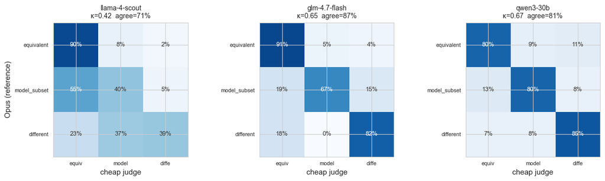

**What this shows:** the diagonal is agreement; the **bottom-left** cell is the unsafe leak (Opus *different* → judge equivalent). Most cheap-judge error is on the `model_subset` row (calling a correct-but-incomplete value 'equivalent') — which is benign for value-correctness — not on the `different` row.

## 4. Cheap consensus — can we skip Opus entirely?

The corpus-scale prize: when the cheap judges agree *with each other*, is that a safe auto-skip with no frontier call? Coverage = share of items where all reliable cheap judges rule OK; leak = of those, how many Opus actually ruled *different*.

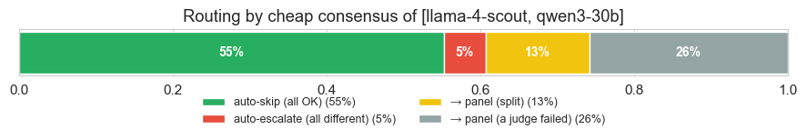

**What this shows:** cheap consensus auto-decides **61%** of items with no frontier call. The auto-skip bucket (**55%** of all items) leaks **3%** — i.e. of values all cheap judges called OK, 3% were actually Opus-*different*. That leak is low enough to make cheap-consensus a viable skip, sending only the split/failed remainder to a frontier panel.

## 5. The three-way — free vs cheap vs frontier

For surface-form confirmation the honest competitor to a cheap LLM isn't Opus, it's the $0 deterministic rule. The leaderboard, cheapest-that-clears-the-bar wins.

**Free vs cheap vs frontier (Opus = the reference, κ=1.00 by definition)**

| judge | $/1M in | n attempted | parse-fail | false-confirm↓ | false-flag (safe) | agree (3-cls) | κ vs Opus |
| --- | --- | --- | --- | --- | --- | --- | --- |
| llama-4-scout | $0.10 | 4,237 | 6% | 61% | 3% | 71% | 0.42 |
| glm-4.7-flash | $0.06 | 1,093 | 78% | 18% | 5% | 87% | 0.65 |
| qwen3-30b | $0.13 | 4,237 | 21% | 15% | 10% | 81% | 0.67 |
| deterministic | $0.00 | 4,237 | 0% | 61% | 13% | 62% | 0.18 |

Opus judge input is **$5.00/1M** — the cheap judges are **82×** cheaper on tokens. But note the deterministic rule (thr=0.3) is free and its false-confirm is **61%** — where it matches a cheap LLM, the LLM buys nothing.

## 6. Per-field — where cheap confirmation is safe

False-confirm isn't uniform across fields. This is the routing output: fields where the best cheap judge rarely leaks can use cheap confirmation; fields where it leaks need frontier review.

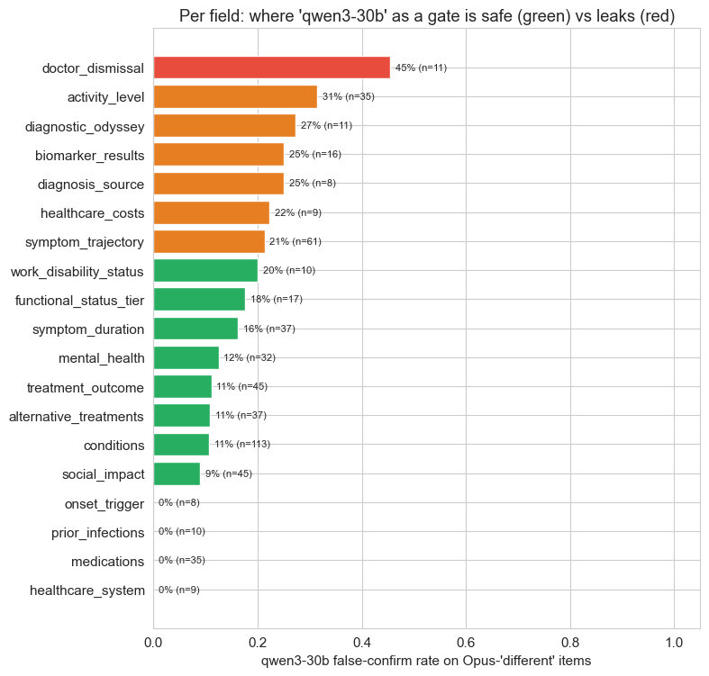

## 7. Verdict

- **Reliability is the first filter, and it's brutal.** llama-4-scout 6% parse-fail; glm-4.7-flash 78% parse-fail; qwen3-30b 21% parse-fail. A cheap judge that can't format is out before accuracy matters — visible only because parse-failure was tracked separately instead of coerced to 'different'.

- **The reliable one is unsafe; the safe one is slow.** `llama-4-scout` formats best (6% fail) but false-confirms **61%** — a *yes-man*, no better than free string-matching (61%). `qwen3-30b` is genuinely safer (15% false-confirm, κ=0.67) but is a reasoning model (21% fail, ~5x tokens, ~20s/call). **No single cheap model is both.**

- **Consensus is the actual gate.** Where the reliable cheap judges (llama-4-scout & qwen3-30b) both say OK — **55%** of items — only **3%** are Opus-*different*. Requiring agreement filters out the yes-man's errors, so cheap *consensus* (not either model alone) is what safely skips the frontier call.

- **Most residual error is benign:** the leak is mostly calling a correct-but-incomplete value 'equivalent' (`model_subset`), not passing a genuinely wrong one.

- **Cheap use = a triage gate, not truth.** This graded mimicry-of-Opus on string-vs-string confirmation with no post in view — it does NOT license a cheap model (or their consensus) as a panel member on the interpretive fields, where the confirm is as hard as the extraction and Opus isn't ground truth.

- **Recommendation:** deterministic first (free) on numeric/ontology/enum -> **cheap consensus [llama-4-scout & qwen3-30b]** as the escalate-on-doubt gate (auto-skip the 55% both-agree, 3% leak) -> frontier panel on the residual + the interpretive fields. Keep solo/disqualified/reasoning judges out of the hot path.

## Research limitations

- **Agreement with Opus is mimicry, not correctness.** High agreement means "safe to substitute for Opus on this task"; *low* agreement is ambiguous (cheap-wrong or Opus-wrong — undecidable here, since Opus is the reference, not ground truth). This validates a cheap *gate*, never a cheap *panel member*.
- **The easy confirm only.** The judge prompt compares two strings and never sees the post, so this measures surface-form confirmation. It says nothing about the hard, post-reading judgment on the interpretive fields.
- **False-confirm is computed on *ruled* items**; a parse-failure is a safe escalate (not a confirm), so the reliability and safety axes must be read together, not traded off.
- **`model_subset` counts as OK** for value-correctness — a judge that under-credits completeness is safe here but a systematically-under-listing extractor is still lossy for clustering (a presence question, not value).
- Measures the correctness/cost of a measurement step, not any treatment effect.

**Provenance**

| item | value |
| --- | --- |
| reference | j11_coding_runs.json |
| reference judge | anthropic/claude-opus-4.8 |
| cheap judges graded | llama-4-scout, glm-4.7-flash, qwen3-30b |
| field-values | 4,237 |
| metric | false-confirm P(judge OK \| Opus different) + reliability |
| det. threshold | 0.3 |
| skill | research-assistant v2 |

These findings reflect the reliability and cost of a measurement step, not population-level treatment effects. This is not medical advice.